# Causality: Success of Leader Assassination

Quantitative Methods for Humanities

CUNEF Universidad, 2025

# Prelude

To run this R Markdown notebook you need the **rmarkdown** package and a CSV reader. We’ll also load the assassination dataset.

```r
# You may need to install these packages… Uncomment if necessary
# install.packages("readr")
library(readr)

# Read the dataset (ensure 'leaders.csv' is in your working directory)
leaders <- read.csv("leaders.csv", stringsAsFactors = FALSE)
```

# Introduction

The role of individual leaders in shaping national trajectories has long fascinated political scientists and historians. Some argue that a leader’s personal attributes—charisma, decisiveness, ideology—can tip the balance of wars, democratization, or collapse. Others emphasize the strength of institutions, culture, and social structures: leaders may be important, but systemic constraints limit their influence.

This tension between **leader-centric** and **institutional** explanations is hard to adjudicate, since leadership transitions in real life are rarely random. However, a grim yet compelling **natural experiment** arises when assassination attempts succeed or fail by chance. If success is effectively random, then comparing subsequent outcomes allows us to estimate the **causal effect** of removing a sitting leader.

In this case study, we use a dataset of assassination attempts against national leaders. Each row is one attempt; key variables include whether the leader died (`result`), measures of democracy (`politybefore` and `polityafter`), and indicators of war before and after. By contrasting countries where the leader was killed with those where the attempt failed, we can assess:

1. How random is assassination success?
2. Do leader removals shift democracy?
3. Do they trigger civil or international war?

# Data Description

The dataset `leaders.csv` has 250 observations on 11 variables, summarized below:

| Variable | Description |
| --- | --- |
| `country` | Country where the attempt occurred |
| `year` | Year of the assassination attempt |
| `leadername` | Name of the leader targeted |
| `age` | Age of the targeted leader |
| `politybefore` | Average Polity score (−10 to +10) in the 3 years prior |
| `polityafter` | Average Polity score in the 3 years after |
| `civilwarbefore` | 1 if in civil war in prior 3 years, 0 otherwise |
| `civilwarafter` | 1 if in civil war in following 3 years, 0 otherwise |
| `interwarbefore` | 1 if in international war in prior 3 years, 0 otherwise |
| `interwarafter` | 1 if in international war in following 3 years, 0 otherwise |
| `result` | Outcome of attempt (e.g., “dies within a day after the attack”, “wounded”, “failed”, etc.) |

# Data exploration

```r
# Summaries of key numeric variables
summary(leaders[, c("age", "politybefore", "polityafter")])
```

```
##       age         politybefore      polityafter
##  Min.   :18.00   Min.   :-10.000   Min.   :-10.000
##  1st Qu.:45.00   1st Qu.: -7.000   1st Qu.: -7.000
##  Median :52.50   Median : -3.000   Median : -3.167
##  Mean   :53.52   Mean   : -1.519   Mean   : -1.650
##  3rd Qu.:61.75   3rd Qu.:  4.000   3rd Qu.:  3.917
##  Max.   :81.00   Max.   : 10.000   Max.   : 10.000
```

```r
# Distribution of result categories
table(leaders$result)
```

```
##
##               dies between a day and a week
##                                           2
##             dies between a week and a month
##                                           2
##          dies within a day after the attack
##                                          46
##                        dies, timing unknown
##                                           4
## hospitalization but no permanent disability
##                                          20
##                                 not wounded
##                                          96
##                                plot stopped
##                                          40
##               survives but wounded severely
##                                           1
##           survives, whether wounded unknown
##                                          14
##                             wounded lightly
##                                          25
```

# Data analysis

## 1. Number of Attempts and Countries

```r
# Compute total attempts, distinct countries, and average per year
total_attempts <- nrow(leaders)
num_countries   <- length(unique(leaders$country))
num_years       <- length(unique(leaders$year))
avg_per_year    <- round(total_attempts / num_years, 2)
```

There are **250** assassination attempts in our sample, spanning **88** distinct countries, for an average of **2.45** attempts per year (over **102** years).

## 2. Success Rate of Assassination Attempts

```r
# Define success: any category in which the leader dies
dead_categories <- c(
  "dies between a day and a week",
  "dies between a week and a month",
  "dies within a day after the attack",
  "dies, timing unknown"
)

leaders$success   <- ifelse(leaders$result %in% dead_categories, 1, 0)
```

From a total of 250 assassination attempts, there were 54 resulting in leader’s death, making a 21.6% of success.

[figure not shown]

Number of Failed vs. Successful Attempts

## 3. Pre-Attempt Characteristics and Conflict by Outcome

```r
# Compute pre-attempt statistics by outcome
polity_before_means  <- tapply(leaders$politybefore, leaders$success, mean)
age_means            <- tapply(leaders$age,           leaders$success, mean)
civil_before_means   <- tapply(leaders$civilwarbefore, leaders$success, mean)
inter_before_means   <- tapply(leaders$interwarbefore, leaders$success, mean)
warbefore_means      <- with(leaders, tapply(
                          ifelse(civilwarbefore==1 | interwarbefore==1, 1, 0),
                          success, mean))
```

- **Average Polity (before):**
  - Failed: -1.74
  - Success: -0.7
- **Average Age:**
  - Failed: 52.7 years
  - Success: 56.5 years
- **Civil War (before):**
  - Failed: 23.5%
  - Success: 14.8%
- **International War (before):**
  - Failed: 17.9%
  - Success: 22.2%
- **Any War (before):**
  - Failed: 37.2%
  - Success: 35.2%

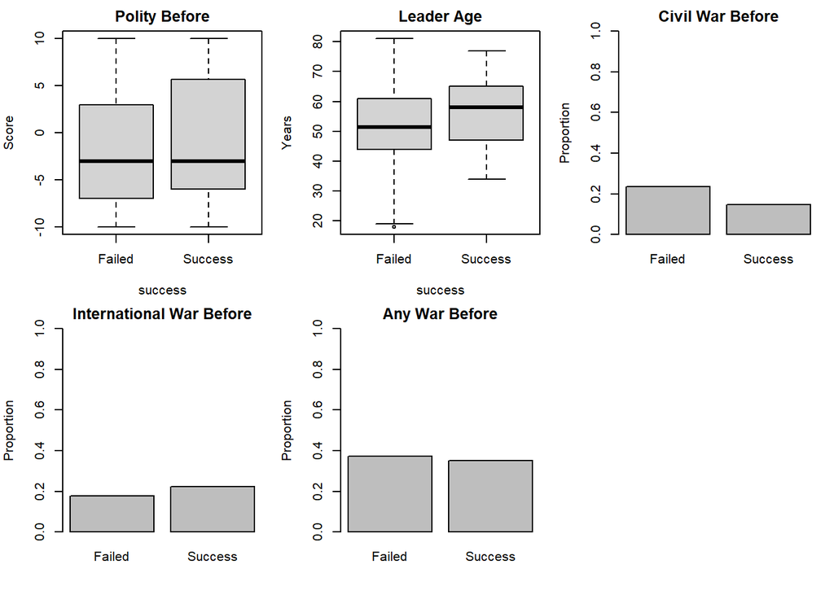

Pre-Attempt Polity, Age, and Conflict by Outcome

Similar medians, means, and spreads for Polity and Age, together with similar pre‐attempt conflict rates, support the assumption that success is effectively random with respect to both regime type, leader characteristics, and conflict environment.

## 5. Effects of Assassination

```r
# Create indicator for war after attempt
leaders$warafter <- ifelse(leaders$civilwarafter == 1 | leaders$interwarafter == 1, 1, 0)

# Compute pre- and post-attempt averages by outcome
polity_before_means <- tapply(leaders$politybefore, leaders$success, mean)
polity_after_means  <- tapply(leaders$polityafter,  leaders$success, mean)

warbefore_means     <- tapply(
  ifelse(leaders$civilwarbefore == 1 | leaders$interwarbefore == 1, 1, 0),
  leaders$success, mean)

warafter_means      <- tapply(leaders$warafter, leaders$success, mean)
```

- **Failed Attempts (success = 0):**
  - Polity before: -1.74
  - Polity after: -1.89
  - **Change:** -0.15
  - War before: 37.2%
  - War after: 29.6%
  - **Change:** -7.7 pp
- **Successful Attempts (success = 1):**
  - Polity before: -0.7
  - Polity after: -0.76
  - **Change:** -0.06
  - War before: 35.2%
  - War after: 20.4%
  - **Change:** -14.8 pp

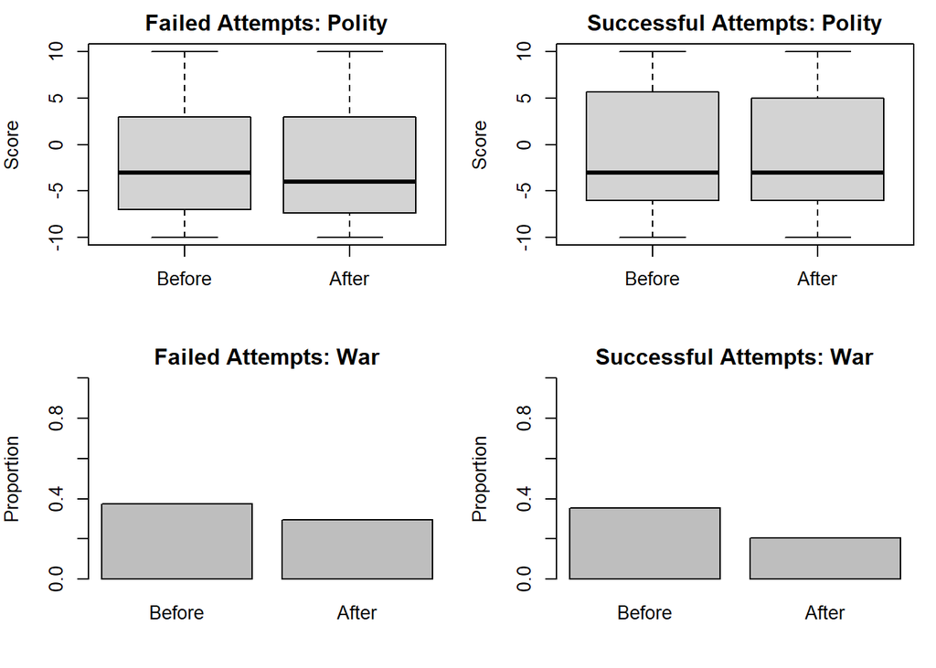

Before and After: Polity and War by Outcome

# Acknowledgement and copyright

These notes adapt material on natural experiments and causal inference from Quantitative Social Science by Kosuke Imai.

© 2025 CUNEF Universidad